# GRC results overview

Stars throughout: * p<0.10, ** p<0.05, *** p<0.01. Standard errors in parentheses.

## Balanced vs unbalanced | IDN consumption, urban

|  | unbalanced none | unbalanced trend | unbalanced +female | unbalanced +age<sup>2</sup> | unbalanced +edu | balanced none | balanced trend | balanced +female | balanced +age<sup>2</sup> | balanced +edu |
| --- | --- | --- | --- | --- | --- | --- | --- | --- | --- | --- |
| *Δ*<sub>never</sub> | 0.304*** | 0.086*** | 0.087*** | 0.091*** | 0.071*** | 0.304*** | 0.051** | 0.051** | 0.051** | 0.040** |
|  | (0.054) | (0.021) | (0.021) | (0.021) | (0.018) | (0.054) | (0.023) | (0.023) | (0.023) | (0.019) |
| *φ* | -2.446*** | -0.310*** | -0.310*** | -0.321*** | -0.525*** | -2.445*** | -0.214** | -0.212** | -0.212** | -0.321*** |
|  | (0.070) | (0.087) | (0.087) | (0.086) | (0.102) | (0.071) | (0.095) | (0.096) | (0.096) | (0.122) |
| *Δ* | 0.381*** | 0.041** | 0.041** | 0.045*** | 0.038** | 0.381*** | 0.017 | 0.017 | 0.017 | 0.016 |
|  | (0.023) | (0.016) | (0.016) | (0.016) | (0.016) | (0.023) | (0.017) | (0.017) | (0.017) | (0.017) |
| *J* p | 0.000 | 0.214 | 0.216 | 0.187 | 0.402 | 0.000 | 0.662 | 0.656 | 0.657 | 0.677 |
| converged | Y | Y | Y | Y | Y | Y | Y | Y | Y | Y |
| *N* | 92,450 | 92,450 | 92,439 | 92,439 | 92,439 | 16,391 | 16,391 | 16,391 | 16,391 | 16,391 |
| runtime | 2773s | 3114s | 3387s | 3385s | 3672s | 552s | 589s | 540s | 552s | 591s |

Results from *unbalanced*: 2026-05-12 10:32 | *balanced*: 2026-05-12 16:00

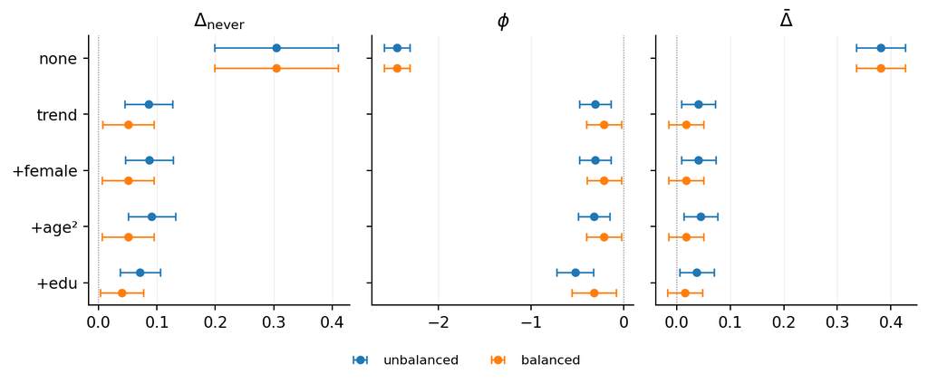

## Balanced vs unbalanced | CHN consumption, urban

|  | unbalanced none | unbalanced trend | unbalanced +female | unbalanced +age<sup>2</sup> | unbalanced +edu | balanced none | balanced trend | balanced +female | balanced +age<sup>2</sup> | balanced +edu |
| --- | --- | --- | --- | --- | --- | --- | --- | --- | --- | --- |
| *Δ*<sub>never</sub> | 0.424*** | 0.090*** | 0.090*** | 0.104*** | 0.098*** | 0.424*** | 0.106*** | 0.106*** | 0.103*** | 0.100*** |
|  | (0.021) | (0.028) | (0.028) | (0.023) | (0.021) | (0.021) | (0.027) | (0.027) | (0.023) | (0.020) |
| *φ* | -0.898*** | -0.073 | -0.073 | -0.161 | -0.205 | -0.897*** | -0.099 | -0.099 | -0.155 | -0.231* |
|  | (0.056) | (0.134) | (0.134) | (0.117) | (0.133) | (0.056) | (0.130) | (0.130) | (0.119) | (0.133) |
| *Δ* | 0.472*** | 0.081*** | 0.081*** | 0.091*** | 0.090*** | 0.472*** | 0.094*** | 0.094*** | 0.092*** | 0.094*** |
|  | (0.021) | (0.021) | (0.021) | (0.021) | (0.021) | (0.021) | (0.021) | (0.021) | (0.021) | (0.021) |
| *J* p | 0.000 | 0.029 | 0.029 | 0.019 | 0.025 | 0.000 | 0.013 | 0.013 | 0.016 | 0.018 |
| converged | Y | Y | Y | Y | Y | Y | Y | Y | Y | Y |
| *N* | 109,535 | 109,535 | 109,535 | 109,535 | 109,535 | 56,855 | 56,855 | 56,855 | 56,855 | 56,855 |
| runtime | 399s | 399s | 461s | 520s | 560s | 169s | 187s | 204s | 227s | 263s |

Results from *unbalanced*: 2026-05-12 15:18 | *balanced*: 2026-05-12 16:44

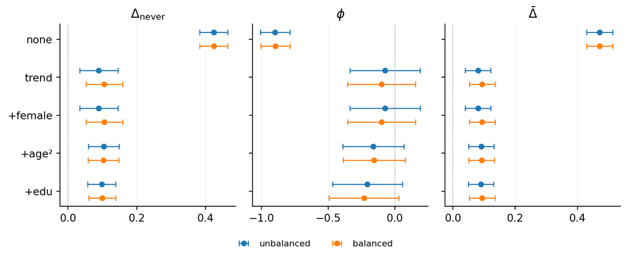

## Balanced vs unbalanced | TZA consumption, urban

|  | unbalanced none | unbalanced trend | unbalanced +female | unbalanced +age<sup>2</sup> | unbalanced +edu | balanced none | balanced trend | balanced +female | balanced +age<sup>2</sup> | balanced +edu |
| --- | --- | --- | --- | --- | --- | --- | --- | --- | --- | --- |
| *Δ*<sub>never</sub> | 0.652*** | 0.301*** | 0.304*** | 0.301*** | 0.270*** | 0.652*** | 0.295*** | 0.298*** | 0.289*** | 0.267*** |
|  | (0.044) | (0.039) | (0.039) | (0.039) | (0.033) | (0.044) | (0.040) | (0.040) | (0.040) | (0.033) |
| *φ* | -1.299*** | -0.515*** | -0.523*** | -0.534*** | -0.719*** | -1.299*** | -0.501*** | -0.508*** | -0.501*** | -0.710*** |
|  | (0.080) | (0.091) | (0.092) | (0.093) | (0.124) | (0.080) | (0.093) | (0.093) | (0.097) | (0.122) |
| *Δ* | 0.056*** | 0.102*** | 0.102*** | 0.103*** | 0.106*** | 0.056*** | 0.102*** | 0.103*** | 0.103*** | 0.107*** |
|  | (0.014) | (0.014) | (0.014) | (0.014) | (0.014) | (0.014) | (0.014) | (0.014) | (0.014) | (0.014) |
| *J* p | 0.021 | 0.084 | 0.089 | 0.084 | 0.280 | 0.021 | 0.060 | 0.063 | 0.048 | 0.405 |
| converged | Y | Y | Y | Y | Y | Y | Y | Y | Y | Y |
| *N* | 29,864 | 29,864 | 29,864 | 29,864 | 29,864 | 23,526 | 23,526 | 23,526 | 23,526 | 23,526 |
| runtime | 25s | 31s | 34s | 39s | 49s | 16s | 21s | 24s | 27s | 37s |

Results from *unbalanced*: 2026-05-12 15:09 | *balanced*: 2026-05-12 16:39

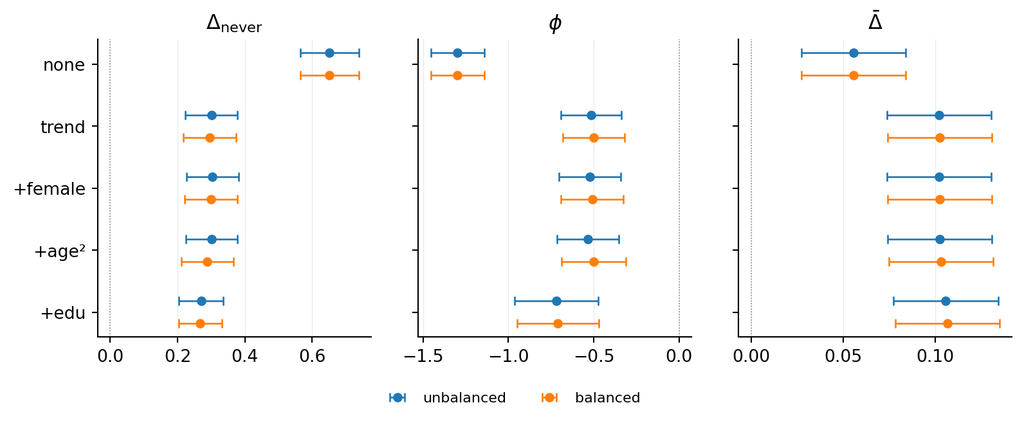

## Main vs experience | IDN consumption, urban (unbalanced)

This table compares our main results for Indonesia to a version that adds years of working experience as a covariate in all columns.

|  | main none | main trend | main +female | main +age<sup>2</sup> | main +edu | experience +exp | experience +female | experience +age<sup>2</sup> | experience +edu |
| --- | --- | --- | --- | --- | --- | --- | --- | --- | --- |
| *Δ*<sub>never</sub> | 0.304*** | 0.086*** | 0.087*** | 0.091*** | 0.071*** | 0.085*** | 0.085*** | 0.090*** | 0.066*** |
|  | (0.054) | (0.021) | (0.021) | (0.021) | (0.018) | (0.021) | (0.021) | (0.021) | (0.018) |
| *φ* | -2.446*** | -0.310*** | -0.310*** | -0.321*** | -0.525*** | -0.305*** | -0.307*** | -0.314*** | -0.472*** |
|  | (0.070) | (0.087) | (0.087) | (0.086) | (0.102) | (0.087) | (0.087) | (0.086) | (0.102) |
| *Δ* | 0.381*** | 0.041** | 0.041** | 0.045*** | 0.038** | 0.039** | 0.040** | 0.043*** | 0.030* |
|  | (0.023) | (0.016) | (0.016) | (0.016) | (0.016) | (0.016) | (0.016) | (0.016) | (0.016) |
| *J* p | 0.000 | 0.214 | 0.216 | 0.187 | 0.402 | 0.224 | 0.223 | 0.200 | 0.461 |
| converged | Y | Y | Y | Y | Y | Y | Y | Y | Y |
| *N* | 92,450 | 92,450 | 92,439 | 92,439 | 92,439 | 92,450 | 92,439 | 92,439 | 92,439 |
| runtime | 2773s | 3114s | 3387s | 3385s | 3672s | 3150s | 3350s | 3896s | 3496s |

Results from *main*: 2026-05-12 10:32 | *experience*: 2026-05-08 13:21

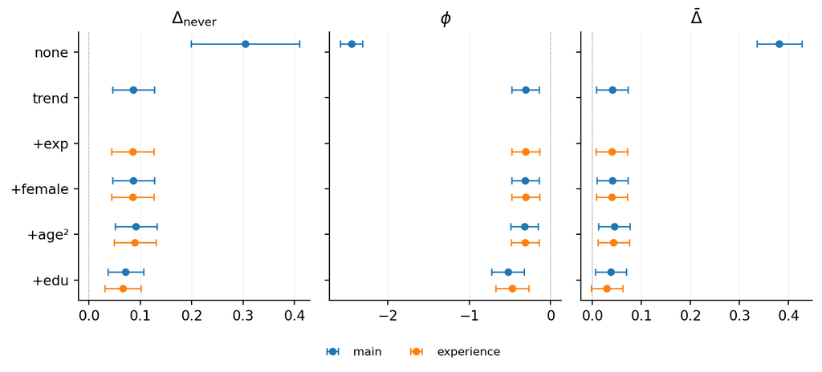

## Main vs max experience | IDN consumption, urban (unbalanced)

This table compares our main results for Indonesia to a version that adds maximum years of working experience (the running max of experience over the panel) as a covariate in all columns.

|  | main none | main trend | main +female | main +age<sup>2</sup> | main +edu | max experience +maxexp | max experience +female | max experience +age<sup>2</sup> | max experience +edu |
| --- | --- | --- | --- | --- | --- | --- | --- | --- | --- |
| *Δ*<sub>never</sub> | 0.304*** | 0.086*** | 0.087*** | 0.091*** | 0.071*** | 0.084*** | 0.084*** | 0.088*** | 0.073*** |
|  | (0.054) | (0.021) | (0.021) | (0.021) | (0.018) | (0.021) | (0.021) | (0.021) | (0.018) |
| *φ* | -2.446*** | -0.310*** | -0.310*** | -0.321*** | -0.525*** | -0.307*** | -0.307*** | -0.317*** | -0.527*** |
|  | (0.070) | (0.087) | (0.087) | (0.086) | (0.102) | (0.088) | (0.088) | (0.088) | (0.101) |
| *Δ* | 0.381*** | 0.041** | 0.041** | 0.045*** | 0.038** | 0.040** | 0.040** | 0.043*** | 0.038** |
|  | (0.023) | (0.016) | (0.016) | (0.016) | (0.016) | (0.016) | (0.016) | (0.016) | (0.016) |
| *J* p | 0.000 | 0.214 | 0.216 | 0.187 | 0.402 | 0.217 | 0.222 | 0.198 | 0.400 |
| converged | Y | Y | Y | Y | Y | Y | Y | Y | Y |
| *N* | 92,450 | 92,450 | 92,439 | 92,439 | 92,439 | 92,450 | 92,439 | 92,439 | 92,439 |
| runtime | 2773s | 3114s | 3387s | 3385s | 3672s | 2966s | 3179s | 3167s | 3308s |

Results from *main*: 2026-05-12 10:32 | *max experience*: 2026-05-08 21:09

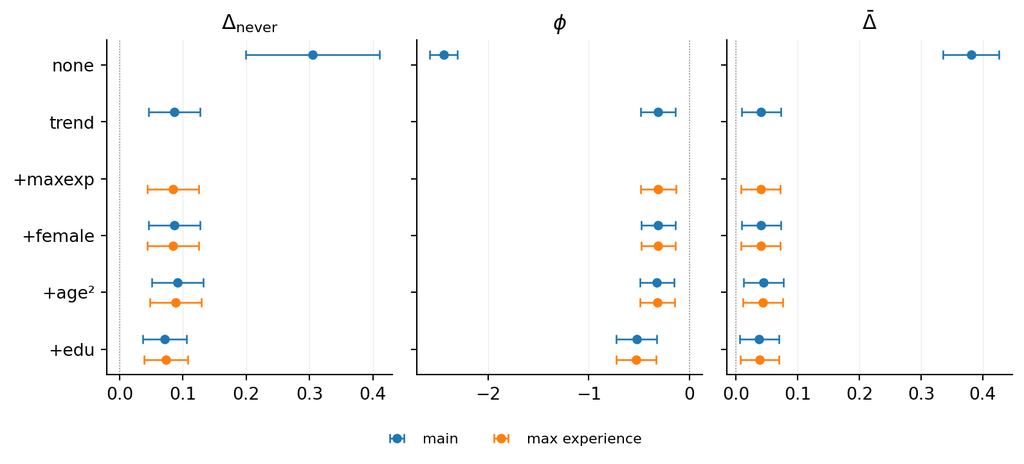

## Main vs experience share | IDN consumption, urban (unbalanced)

This table compares our main results for Indonesia to a version that adds the experience share (years of experience normalized by potential working years) as a covariate in all columns.

|  | main none | main trend | main +female | main +age<sup>2</sup> | main +edu | experience share +expsh | experience share +female | experience share +age<sup>2</sup> | experience share +edu |
| --- | --- | --- | --- | --- | --- | --- | --- | --- | --- |
| *Δ*<sub>never</sub> | 0.304*** | 0.086*** | 0.087*** | 0.091*** | 0.071*** | 0.086*** | 0.087*** | 0.092*** | 0.074*** |
|  | (0.054) | (0.021) | (0.021) | (0.021) | (0.018) | (0.021) | (0.021) | (0.021) | (0.018) |
| *φ* | -2.446*** | -0.310*** | -0.310*** | -0.321*** | -0.525*** | -0.309*** | -0.310*** | -0.320*** | -0.495*** |
|  | (0.070) | (0.087) | (0.087) | (0.086) | (0.102) | (0.087) | (0.087) | (0.086) | (0.101) |
| *Δ* | 0.381*** | 0.041** | 0.041** | 0.045*** | 0.038** | 0.040** | 0.041** | 0.045*** | 0.037** |
|  | (0.023) | (0.016) | (0.016) | (0.016) | (0.016) | (0.016) | (0.016) | (0.016) | (0.016) |
| *J* p | 0.000 | 0.214 | 0.216 | 0.187 | 0.402 | 0.216 | 0.216 | 0.188 | 0.406 |
| converged | Y | Y | Y | Y | Y | Y | Y | Y | Y |
| *N* | 92,450 | 92,450 | 92,439 | 92,439 | 92,439 | 92,450 | 92,439 | 92,439 | 92,439 |
| runtime | 2773s | 3114s | 3387s | 3385s | 3672s | 2894s | 2975s | 3079s | 3294s |

Results from *main*: 2026-05-12 10:32 | *experience share*: 2026-05-09 04:30

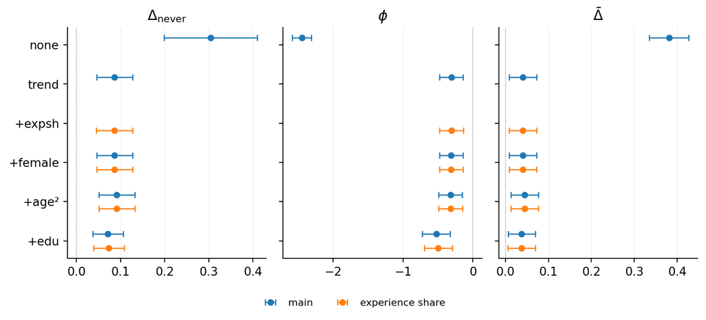

## Main vs max experience share | IDN consumption, urban (unbalanced)

This table compares our main results for Indonesia to a version that adds the running max of experience share as a covariate in all columns.

|  | main none | main trend | main +female | main +age<sup>2</sup> | main +edu | max experience share +maxexpsh | max experience share +female | max experience share +age<sup>2</sup> | max experience share +edu |
| --- | --- | --- | --- | --- | --- | --- | --- | --- | --- |
| *Δ*<sub>never</sub> | 0.304*** | 0.086*** | 0.087*** | 0.091*** | 0.071*** | 0.086*** | 0.086*** | 0.091*** | 0.074*** |
|  | (0.054) | (0.021) | (0.021) | (0.021) | (0.018) | (0.021) | (0.021) | (0.021) | (0.018) |
| *φ* | -2.446*** | -0.310*** | -0.310*** | -0.321*** | -0.525*** | -0.310*** | -0.310*** | -0.321*** | -0.523*** |
|  | (0.070) | (0.087) | (0.087) | (0.086) | (0.102) | (0.087) | (0.087) | (0.087) | (0.100) |
| *Δ* | 0.381*** | 0.041** | 0.041** | 0.045*** | 0.038** | 0.041** | 0.041** | 0.045*** | 0.038** |
|  | (0.023) | (0.016) | (0.016) | (0.016) | (0.016) | (0.016) | (0.016) | (0.016) | (0.016) |
| *J* p | 0.000 | 0.214 | 0.216 | 0.187 | 0.402 | 0.213 | 0.216 | 0.188 | 0.405 |
| converged | Y | Y | Y | Y | Y | Y | Y | Y | Y |
| *N* | 92,450 | 92,450 | 92,439 | 92,439 | 92,439 | 92,450 | 92,439 | 92,439 | 92,439 |
| runtime | 2773s | 3114s | 3387s | 3385s | 3672s | 3221s | 3940s | 4217s | 4382s |

Results from *main*: 2026-05-12 10:32 | *max experience share*: 2026-05-09 11:48

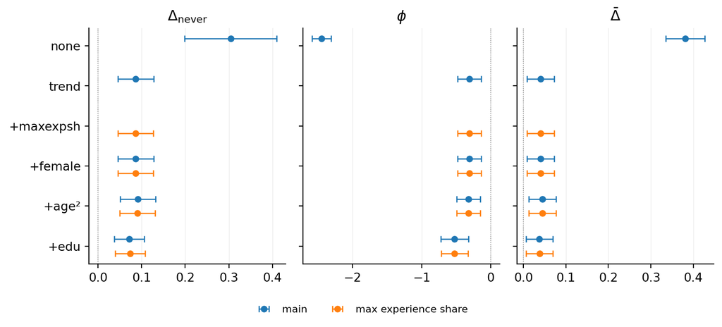

## Main vs urban birth | IDN consumption, urban (unbalanced)

This table compares our main results for Indonesia to a version that adds an indicator for being born in an urban location as a covariate in all columns.

|  | main none | main trend | main +female | main +age<sup>2</sup> | main +edu | urban birth +birth | urban birth +female | urban birth +age<sup>2</sup> | urban birth +edu |
| --- | --- | --- | --- | --- | --- | --- | --- | --- | --- |
| *Δ*<sub>never</sub> | 0.304*** | 0.086*** | 0.087*** | 0.091*** | 0.071*** | 0.078*** | 0.079*** | 0.081*** | 0.068*** |
|  | (0.054) | (0.021) | (0.021) | (0.021) | (0.018) | (0.020) | (0.020) | (0.020) | (0.017) |
| *φ* | -2.446*** | -0.310*** | -0.310*** | -0.321*** | -0.525*** | -0.303*** | -0.303*** | -0.308*** | -0.520*** |
|  | (0.070) | (0.087) | (0.087) | (0.086) | (0.102) | (0.092) | (0.092) | (0.091) | (0.104) |
| *Δ* | 0.381*** | 0.041** | 0.041** | 0.045*** | 0.038** | 0.040** | 0.040** | 0.041** | 0.037** |
|  | (0.023) | (0.016) | (0.016) | (0.016) | (0.016) | (0.016) | (0.016) | (0.016) | (0.016) |
| *J* p | 0.000 | 0.214 | 0.216 | 0.187 | 0.402 | 0.176 | 0.178 | 0.168 | 0.378 |
| converged | Y | Y | Y | Y | Y | Y | Y | Y | Y |
| *N* | 92,450 | 92,450 | 92,439 | 92,439 | 92,439 | 92,221 | 92,210 | 92,210 | 92,210 |
| runtime | 2773s | 3114s | 3387s | 3385s | 3672s | 3948s | 4066s | 4039s | 4324s |

Results from *main*: 2026-05-12 10:32 | *urban birth*: 2026-05-11 15:54

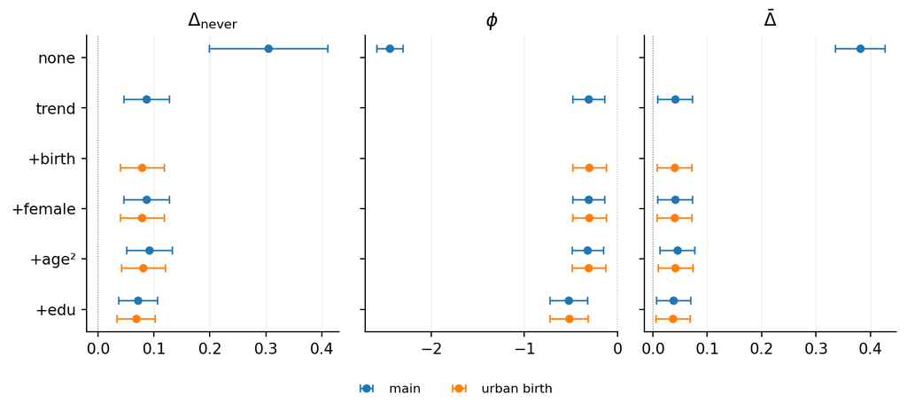

## Main vs rural-first hukou | CHN consumption, urban (unbalanced)

This table compares our main results for China to a version that restricts the sample to individuals whose initial recorded hukou is rural.

|  | main none | main trend | main +female | main +age<sup>2</sup> | main +edu | rural-first none | rural-first trend | rural-first +female | rural-first +age<sup>2</sup> | rural-first +edu |
| --- | --- | --- | --- | --- | --- | --- | --- | --- | --- | --- |
| *Δ*<sub>never</sub> | 0.424*** | 0.090*** | 0.090*** | 0.104*** | 0.098*** | 0.421*** | 0.074** | 0.074** | 0.105*** | 0.106*** |
|  | (0.021) | (0.028) | (0.028) | (0.023) | (0.021) | (0.022) | (0.036) | (0.036) | (0.025) | (0.023) |
| *φ* | -0.898*** | -0.073 | -0.073 | -0.161 | -0.205 | -0.893*** | 0.129 | 0.128 | -0.037 | -0.039 |
|  | (0.056) | (0.134) | (0.134) | (0.117) | (0.133) | (0.070) | (0.193) | (0.193) | (0.152) | (0.153) |
| *Δ* | 0.472*** | 0.081*** | 0.081*** | 0.091*** | 0.090*** | 0.481*** | 0.089*** | 0.089*** | 0.102*** | 0.104*** |
|  | (0.021) | (0.021) | (0.021) | (0.021) | (0.021) | (0.022) | (0.022) | (0.022) | (0.022) | (0.022) |
| *J* p | 0.000 | 0.029 | 0.029 | 0.019 | 0.025 | 0.000 | 0.209 | 0.209 | 0.126 | 0.125 |
| converged | Y | Y | Y | Y | Y | Y | Y | Y | Y | Y |
| *N* | 109,535 | 109,535 | 109,535 | 109,535 | 109,535 | 80,742 | 80,742 | 80,742 | 80,742 | 80,742 |
| runtime | 399s | 399s | 461s | 520s | 560s | 336s | 339s | 353s | 383s | 426s |

Results from *main*: 2026-05-12 15:18 | *rural-first*: 2026-05-12 23:52

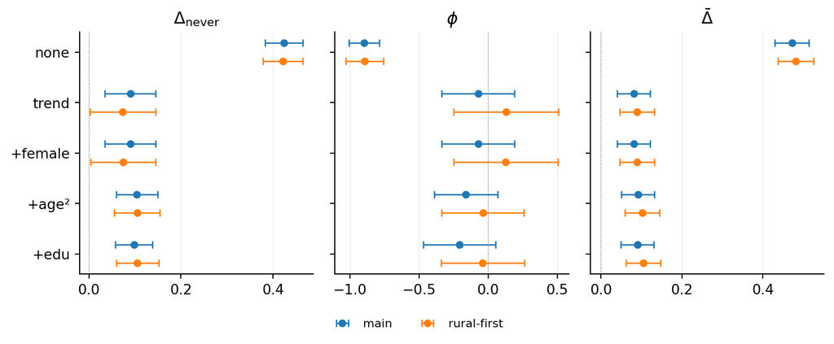

## Main vs rural-only hukou | CHN consumption, urban (unbalanced)

This table compares our main results for China to a version that restricts the sample to individuals whose recorded hukou stays rural in every wave.

|  | main none | main trend | main +female | main +age<sup>2</sup> | main +edu | rural-only none | rural-only trend | rural-only +female | rural-only +age<sup>2</sup> | rural-only +edu |
| --- | --- | --- | --- | --- | --- | --- | --- | --- | --- | --- |
| *Δ*<sub>never</sub> | 0.424*** | 0.090*** | 0.090*** | 0.104*** | 0.098*** | 0.497*** | 0.075** | 0.075** | 0.098*** | 0.100*** |
|  | (0.021) | (0.028) | (0.028) | (0.023) | (0.021) | (0.024) | (0.032) | (0.032) | (0.025) | (0.023) |
| *φ* | -0.898*** | -0.073 | -0.073 | -0.161 | -0.205 | -0.289*** | 0.088 | 0.087 | -0.021 | -0.032 |
|  | (0.056) | (0.134) | (0.134) | (0.117) | (0.133) | (0.104) | (0.176) | (0.175) | (0.151) | (0.152) |
| *Δ* | 0.472*** | 0.081*** | 0.081*** | 0.091*** | 0.090*** | 0.526*** | 0.085*** | 0.085*** | 0.097*** | 0.099*** |
|  | (0.021) | (0.021) | (0.021) | (0.021) | (0.021) | (0.024) | (0.022) | (0.022) | (0.022) | (0.022) |
| *J* p | 0.000 | 0.029 | 0.029 | 0.019 | 0.025 | 0.000 | 0.286 | 0.285 | 0.208 | 0.200 |
| converged | Y | Y | Y | Y | Y | Y | Y | Y | Y | Y |
| *N* | 109,535 | 109,535 | 109,535 | 109,535 | 109,535 | 75,748 | 75,748 | 75,748 | 75,748 | 75,748 |
| runtime | 399s | 399s | 461s | 520s | 560s | 265s | 271s | 296s | 326s | 366s |

Results from *main*: 2026-05-12 15:18 | *rural-only*: 2026-05-13 00:50

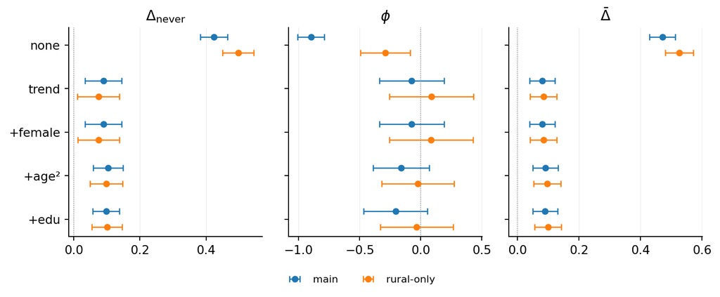

## Main vs urban-only hukou | CHN consumption, urban (unbalanced)

This table compares our main results for China to a version that restricts the sample to individuals whose recorded hukou stays urban in every wave.

|  | main none | main trend | main +female | main +age<sup>2</sup> | main +edu | urban-only none | urban-only trend | urban-only +female | urban-only +age<sup>2</sup> | urban-only +edu |
| --- | --- | --- | --- | --- | --- | --- | --- | --- | --- | --- |
| *Δ*<sub>never</sub> | 0.424*** | 0.090*** | 0.090*** | 0.104*** | 0.098*** | 0.242*** | 0.078 | 0.079 | 0.045 | -0.024 |
|  | (0.021) | (0.028) | (0.028) | (0.023) | (0.021) | (0.071) | (0.054) | (0.054) | (0.053) | (0.057) |
| *φ* | -0.898*** | -0.073 | -0.073 | -0.161 | -0.205 | -1.276*** | -0.791*** | -0.798*** | -0.820*** | -0.976*** |
|  | (0.056) | (0.134) | (0.134) | (0.117) | (0.133) | (0.137) | (0.155) | (0.158) | (0.155) | (0.172) |
| *Δ* | 0.472*** | 0.081*** | 0.081*** | 0.091*** | 0.090*** | 0.295*** | 0.052 | 0.053 | 0.050 | 0.045 |
|  | (0.021) | (0.021) | (0.021) | (0.021) | (0.021) | (0.053) | (0.053) | (0.053) | (0.052) | (0.051) |
| *J* p | 0.000 | 0.029 | 0.029 | 0.019 | 0.025 | 0.759 | 0.174 | 0.163 | 0.230 | 0.303 |
| converged | Y | Y | Y | Y | Y | Y | Y | Y | Y | Y |
| *N* | 109,535 | 109,535 | 109,535 | 109,535 | 109,535 | 26,155 | 26,155 | 26,155 | 26,155 | 26,155 |
| runtime | 399s | 399s | 461s | 520s | 560s | 26s | 39s | 47s | 49s | 58s |

Results from *main*: 2026-05-12 15:18 | *urban-only*: 2026-05-13 01:28

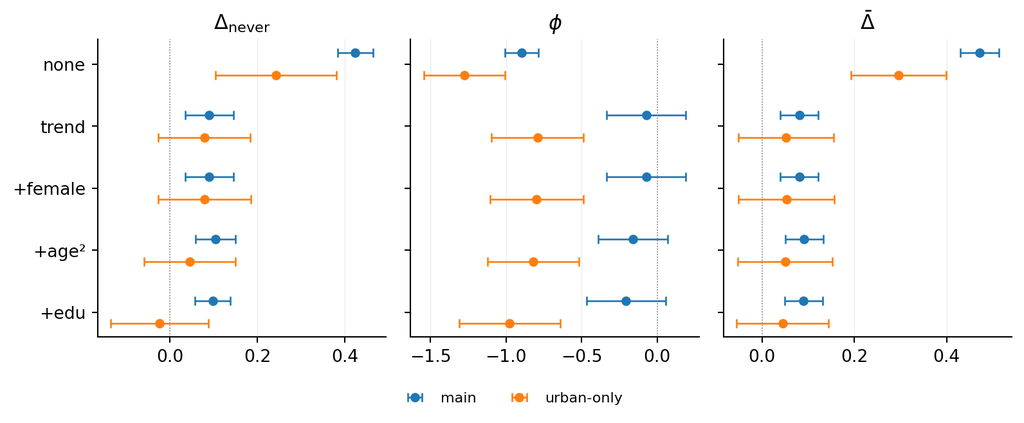

## Main vs urban-first hukou | CHN consumption, urban (unbalanced)

This table compares our main results for China to a version that restricts the sample to individuals whose initial recorded hukou is urban.

|  | main none | main trend | main +female | main +age<sup>2</sup> | main +edu | urban-first none | urban-first trend | urban-first +female | urban-first +age<sup>2</sup> | urban-first +edu |
| --- | --- | --- | --- | --- | --- | --- | --- | --- | --- | --- |
| *Δ*<sub>never</sub> | 0.424*** | 0.090*** | 0.090*** | 0.104*** | 0.098*** | 0.284*** | 0.106* | 0.107* | 0.074 | 0.006 |
|  | (0.021) | (0.028) | (0.028) | (0.023) | (0.021) | (0.074) | (0.055) | (0.055) | (0.053) | (0.054) |
| *φ* | -0.898*** | -0.073 | -0.073 | -0.161 | -0.205 | -1.324*** | -0.805*** | -0.804*** | -0.826*** | -0.973*** |
|  | (0.056) | (0.134) | (0.134) | (0.117) | (0.133) | (0.165) | (0.162) | (0.162) | (0.158) | (0.169) |
| *Δ* | 0.472*** | 0.081*** | 0.081*** | 0.091*** | 0.090*** | 0.330*** | 0.052 | 0.053 | 0.052 | 0.004 |
|  | (0.021) | (0.021) | (0.021) | (0.021) | (0.021) | (0.050) | (0.054) | (0.054) | (0.054) | (0.378) |
| *J* p | 0.000 | 0.029 | 0.029 | 0.019 | 0.025 | 0.585 | 0.108 | 0.100 | 0.126 | 0.215 |
| converged | Y | Y | Y | Y | Y | Y | Y | Y | Y | Y |
| *N* | 109,535 | 109,535 | 109,535 | 109,535 | 109,535 | 28,264 | 28,264 | 28,264 | 28,264 | 28,264 |
| runtime | 399s | 399s | 461s | 520s | 560s | 43s | 57s | 70s | 66s | 123s |

Results from *main*: 2026-05-12 15:18 | *urban-first*: 2026-05-13 00:36

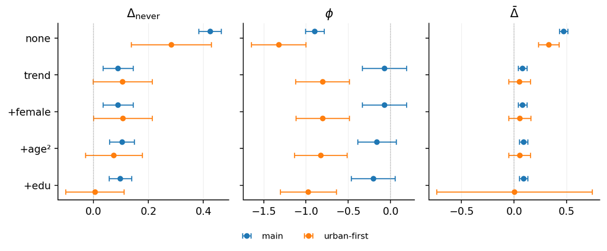

## Main (urban) vs non-agricultural | IDN consumption (unbalanced)

This table compares our main results for Indonesia to a version that uses non-agricultural employment instead of urban location as the treatment.

|  | main none | main trend | main +female | main +age<sup>2</sup> | main +edu | non-ag none | non-ag trend | non-ag +female | non-ag +age<sup>2</sup> | non-ag +edu |
| --- | --- | --- | --- | --- | --- | --- | --- | --- | --- | --- |
| *Δ*<sub>never</sub> | 0.304*** | 0.086*** | 0.087*** | 0.091*** | 0.071*** | 0.271*** | -0.051 | -0.052 | -0.052 | -1.014 |
|  | (0.054) | (0.021) | (0.021) | (0.021) | (0.018) | (0.050) | (0.049) | (0.050) | (0.050) | (3.081) |
| *φ* | -2.446*** | -0.310*** | -0.310*** | -0.321*** | -0.525*** | -2.226*** | 0.794** | 0.810** | 0.804** | 15.301 |
|  | (0.070) | (0.087) | (0.087) | (0.086) | (0.102) | (0.101) | (0.357) | (0.364) | (0.360) | (44.442) |
| *Δ* | 0.381*** | 0.041** | 0.041** | 0.045*** | 0.038** | 0.049 | 0.047*** | 0.047*** | 0.049*** | 0.051*** |
|  | (0.023) | (0.016) | (0.016) | (0.016) | (0.016) | (0.032) | (0.017) | (0.017) | (0.017) | (0.017) |
| *J* p | 0.000 | 0.214 | 0.216 | 0.187 | 0.402 | 0.000 | 0.074 | 0.075 | 0.205 | 0.207 |
| converged | Y | Y | Y | Y | Y | Y | Y | Y | Y | Y |
| *N* | 92,450 | 92,450 | 92,439 | 92,439 | 92,439 | 69,447 | 69,447 | 69,445 | 69,445 | 69,445 |
| runtime | 2773s | 3114s | 3387s | 3385s | 3672s | 1962s | 2435s | 2687s | 2815s | 3533s |

Results from *main*: 2026-05-12 10:32 | *non-ag*: 2026-05-12 20:33

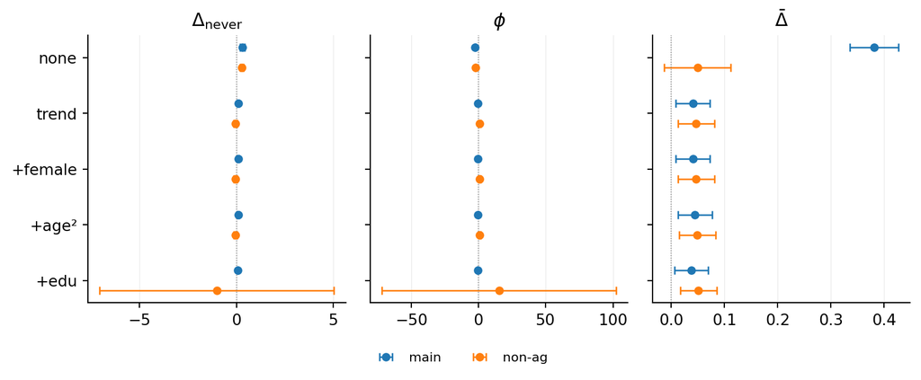

## Main (consumption) vs income | IDN urban (unbalanced)

This table compares our main results for Indonesia to a version that uses log per-capita income as the dependent variable instead of log per-capita consumption.

|  | consumption none | consumption trend | consumption +female | consumption +age<sup>2</sup> | consumption +edu | income none | income trend | income +female | income +age<sup>2</sup> | income +edu |
| --- | --- | --- | --- | --- | --- | --- | --- | --- | --- | --- |
| *Δ*<sub>never</sub> | 0.304*** | 0.086*** | 0.087*** | 0.091*** | 0.071*** | 0.158*** | -0.155** | -0.188*** | 0.010 | -0.015 |
|  | (0.054) | (0.021) | (0.021) | (0.021) | (0.018) | (0.032) | (0.065) | (0.069) | (0.049) | (0.050) |
| *φ* | -2.446*** | -0.310*** | -0.310*** | -0.321*** | -0.525*** | -0.046 | 0.453*** | 0.543*** | 0.223* | 0.444** |
|  | (0.070) | (0.087) | (0.087) | (0.086) | (0.102) | (0.074) | (0.165) | (0.175) | (0.120) | (0.196) |
| *Δ* | 0.381*** | 0.041** | 0.041** | 0.045*** | 0.038** | 0.149*** | -0.024 | -0.024 | 0.066** | 0.050* |
|  | (0.023) | (0.016) | (0.016) | (0.016) | (0.016) | (0.024) | (0.028) | (0.028) | (0.028) | (0.027) |
| *J* p | 0.000 | 0.214 | 0.216 | 0.187 | 0.402 | 0.128 | 0.216 | 0.316 | 0.043 | 0.072 |
| converged | Y | Y | Y | Y | Y | Y | Y | Y | Y | Y |
| *N* | 92,450 | 92,450 | 92,439 | 92,439 | 92,439 | 58,047 | 58,047 | 58,045 | 58,045 | 58,045 |
| runtime | 2773s | 3114s | 3387s | 3385s | 3672s | 1696s | 1843s | 2023s | 2033s | 2190s |

Results from *consumption*: 2026-05-12 10:32 | *income*: 2026-05-12 17:27

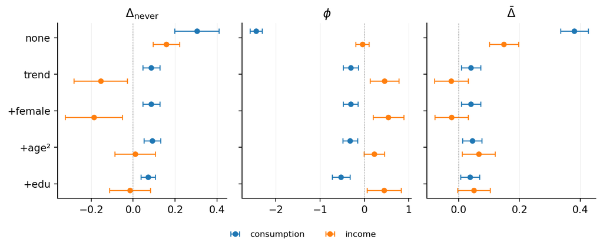

# Real values

The sections below compare nominal (default) results to the same specification estimated on real (deflated) values of the dependent variable. Nominal columns load from on-disk `.ster` files; real columns currently pull headline values from a bank scraped from the RP6-real Stata logs (see `tools/results_overview/scrape_logs.py`). Once we re-run the M4 real pipeline locally, the bank fallback will be replaced with on-disk `_r`-suffix `.ster` files, and the `runtime` row will populate.

## Nominal vs real | IDN consumption, urban (unbalanced)

|  | nominal none | nominal trend | nominal +female | nominal +age<sup>2</sup> | nominal +edu | real none | real trend | real +female | real +age<sup>2</sup> | real +edu |
| --- | --- | --- | --- | --- | --- | --- | --- | --- | --- | --- |
| *Δ*<sub>never</sub> | 0.304*** | 0.086*** | 0.087*** | 0.091*** | 0.071*** | 0.262*** | -0.015 | -0.015 | -0.012 | -0.029 |
|  | (0.054) | (0.021) | (0.021) | (0.021) | (0.018) | (0.058) | (0.021) | (0.021) | (0.021) | (0.018) |
| *φ* | -2.446*** | -0.310*** | -0.310*** | -0.321*** | -0.525*** | -2.069*** | -0.256*** | -0.257*** | -0.262*** | -0.442*** |
|  | (0.070) | (0.087) | (0.087) | (0.086) | (0.102) | (0.124) | (0.092) | (0.092) | (0.092) | (0.116) |
| *Δ* | 0.381*** | 0.041** | 0.041** | 0.045*** | 0.038** | -0.024*** | -0.004*** | -0.004*** | -0.004*** | -0.004*** |
|  | (0.023) | (0.016) | (0.016) | (0.016) | (0.016) | (0.001) | (0.001) | (0.001) | (0.001) | (0.001) |
| *J* p | 0.000 | 0.214 | 0.216 | 0.187 | 0.402 | 0.000 | 0.170 | 0.170 | 0.153 | 0.287 |
| converged | Y | Y | Y | Y | Y |  |  |  |  |  |
| *N* | 92,450 | 92,450 | 92,439 | 92,439 | 92,439 | 92,450 | 92,450 | 92,439 | 92,439 | 92,439 |
| runtime | 2773s | 3114s | 3387s | 3385s | 3672s |  |  |  |  |  |

Results from *nominal*: 2026-05-12 10:32 | *real*: scraped from log

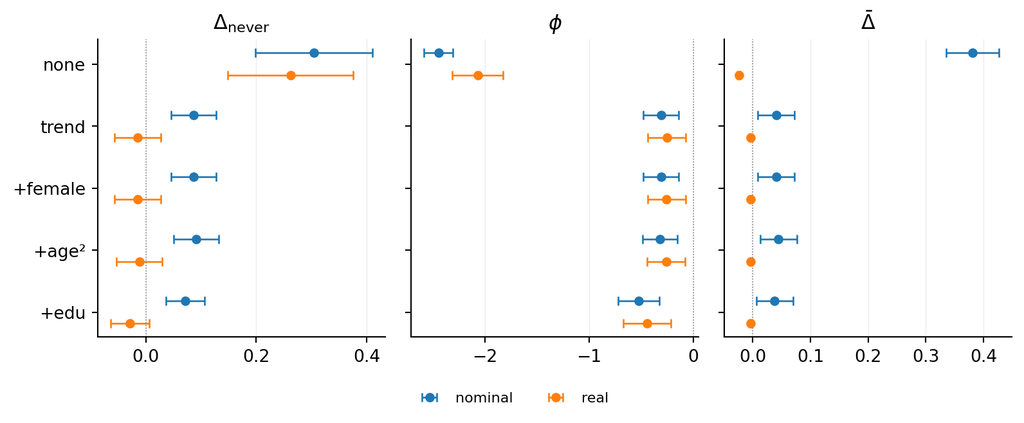

## Nominal vs real | CHN consumption, urban (unbalanced)

|  | nominal none | nominal trend | nominal +female | nominal +age<sup>2</sup> | nominal +edu | real none | real trend | real +female | real +age<sup>2</sup> | real +edu |
| --- | --- | --- | --- | --- | --- | --- | --- | --- | --- | --- |
| *Δ*<sub>never</sub> | 0.424*** | 0.090*** | 0.090*** | 0.104*** | 0.098*** | 0.156*** | -0.135*** | -0.135*** | -0.123*** | -0.130*** |
|  | (0.021) | (0.028) | (0.028) | (0.023) | (0.021) | (0.021) | (0.027) | (0.027) | (0.023) | (0.020) |
| *φ* | -0.898*** | -0.073 | -0.073 | -0.161 | -0.205 | -0.888*** | -0.086 | -0.086 | -0.172 | -0.222* |
|  | (0.056) | (0.134) | (0.134) | (0.117) | (0.133) | (0.063) | (0.132) | (0.132) | (0.116) | (0.132) |
| *Δ* | 0.472*** | 0.081*** | 0.081*** | 0.091*** | 0.090*** | 0.007*** | -0.006*** | -0.006*** | -0.006*** | -0.006*** |
|  | (0.021) | (0.021) | (0.021) | (0.021) | (0.021) | (0.001) | (0.001) | (0.001) | (0.001) | (0.001) |
| *J* p | 0.000 | 0.029 | 0.029 | 0.019 | 0.025 | 0.000 | 0.016 | 0.016 | 0.009 | 0.012 |
| converged | Y | Y | Y | Y | Y |  |  |  |  |  |
| *N* | 109,535 | 109,535 | 109,535 | 109,535 | 109,535 | 109,535 | 109,535 | 109,535 | 109,535 | 109,535 |
| runtime | 399s | 399s | 461s | 520s | 560s |  |  |  |  |  |

Results from *nominal*: 2026-05-12 15:18 | *real*: scraped from log

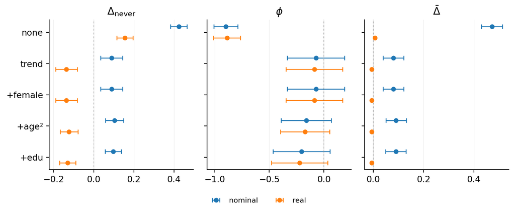

## Nominal vs real | TZA consumption, urban (unbalanced)

|  | nominal none | nominal trend | nominal +female | nominal +age<sup>2</sup> | nominal +edu | real none | real trend | real +female | real +age<sup>2</sup> | real +edu |
| --- | --- | --- | --- | --- | --- | --- | --- | --- | --- | --- |
| *Δ*<sub>never</sub> | 0.652*** | 0.301*** | 0.304*** | 0.301*** | 0.270*** | 0.239*** | 0.240*** | 0.242*** | 0.240*** | 0.204*** |
|  | (0.044) | (0.039) | (0.039) | (0.039) | (0.033) | (0.033) | (0.033) | (0.033) | (0.033) | (0.034) |
| *φ* | -1.299*** | -0.515*** | -0.523*** | -0.534*** | -0.719*** | -0.601*** | -0.602*** | -0.609*** | -0.624*** | -0.858*** |
|  | (0.080) | (0.091) | (0.092) | (0.093) | (0.124) | (0.075) | (0.077) | (0.077) | (0.078) | (0.135) |
| *Δ* | 0.056*** | 0.102*** | 0.102*** | 0.103*** | 0.106*** | 0.002 | 0.002 | 0.002 | 0.002 | 0.003* |
|  | (0.014) | (0.014) | (0.014) | (0.014) | (0.014) | (0.002) | (0.002) | (0.002) | (0.002) | (0.002) |
| *J* p | 0.021 | 0.084 | 0.089 | 0.084 | 0.280 | 0.336 | 0.239 | 0.252 | 0.238 | 0.065 |
| converged | Y | Y | Y | Y | Y |  |  |  |  |  |
| *N* | 29,864 | 29,864 | 29,864 | 29,864 | 29,864 | 29,864 | 29,864 | 29,864 | 29,864 | 29,864 |
| runtime | 25s | 31s | 34s | 39s | 49s |  |  |  |  |  |

Results from *nominal*: 2026-05-12 15:09 | *real*: scraped from log

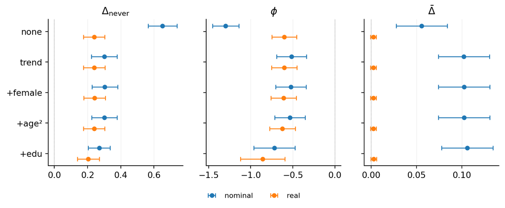

## Nominal vs real | IDN consumption, urban, experience family (unbalanced)

|  | nominal +exp | nominal +female | nominal +age<sup>2</sup> | nominal +edu | real +exp | real +female | real +age<sup>2</sup> | real +edu |
| --- | --- | --- | --- | --- | --- | --- | --- | --- |
| *Δ*<sub>never</sub> | 0.085*** | 0.085*** | 0.090*** | 0.066*** | -0.017 | -0.017 | -0.014 | -0.033* |
|  | (0.021) | (0.021) | (0.021) | (0.018) | (0.022) | (0.022) | (0.021) | (0.018) |
| *φ* | -0.305*** | -0.307*** | -0.314*** | -0.472*** | -0.251*** | -0.251*** | -0.256*** | -0.414*** |
|  | (0.087) | (0.087) | (0.086) | (0.102) | (0.093) | (0.093) | (0.092) | (0.116) |
| *Δ* | 0.039** | 0.040** | 0.043*** | 0.030* | -0.004*** | -0.004*** | -0.004*** | -0.005*** |
|  | (0.016) | (0.016) | (0.016) | (0.016) | (0.001) | (0.001) | (0.001) | (0.001) |
| *J* p | 0.224 | 0.223 | 0.200 | 0.461 | 0.183 | 0.183 | 0.167 | 0.358 |
| converged | Y | Y | Y | Y |  |  |  |  |
| *N* | 92,450 | 92,439 | 92,439 | 92,439 | 92,450 | 92,439 | 92,439 | 92,439 |
| runtime | 3150s | 3350s | 3896s | 3496s |  |  |  |  |

Results from *nominal*: 2026-05-08 13:21 | *real*: scraped from log

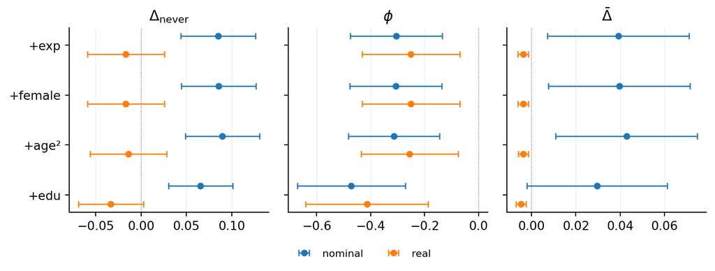

## Nominal vs real | IDN consumption, urban, urban-birth family (unbalanced)

|  | nominal +birth | nominal +female | nominal +age<sup>2</sup> | nominal +edu | real +birth | real +female | real +age<sup>2</sup> | real +edu |
| --- | --- | --- | --- | --- | --- | --- | --- | --- |
| *Δ*<sub>never</sub> | 0.078*** | 0.079*** | 0.081*** | 0.068*** | -0.021 | -0.020 | -0.020 | -0.029 |
|  | (0.020) | (0.020) | (0.020) | (0.017) | (0.021) | (0.021) | (0.021) | (0.018) |
| *φ* | -0.303*** | -0.303*** | -0.308*** | -0.520*** | -0.243** | -0.244** | -0.246** | -0.442*** |
|  | (0.092) | (0.092) | (0.091) | (0.104) | (0.096) | (0.096) | (0.096) | (0.116) |
| *Δ* | 0.040** | 0.040** | 0.041** | 0.037** | -0.004*** | -0.004*** | -0.004*** | -0.004*** |
|  | (0.016) | (0.016) | (0.016) | (0.016) | (0.001) | (0.001) | (0.001) | (0.001) |
| *J* p | 0.176 | 0.178 | 0.168 | 0.378 | 0.147 | 0.148 | 0.143 | 0.284 |
| converged | Y | Y | Y | Y |  |  |  |  |
| *N* | 92,221 | 92,210 | 92,210 | 92,210 | 92,221 | 92,210 | 92,210 | 92,210 |
| runtime | 3948s | 4066s | 4039s | 4324s |  |  |  |  |

Results from *nominal*: 2026-05-11 15:54 | *real*: scraped from log

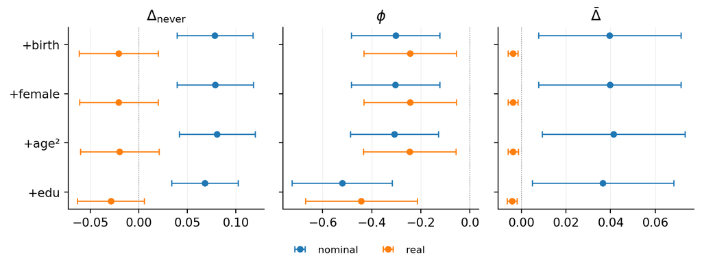

## Nominal vs real | IDN consumption, non-agricultural (unbalanced)

|  | nominal none | nominal trend | nominal +female | nominal +age<sup>2</sup> | nominal +edu | real none | real trend | real +female | real +age<sup>2</sup> | real +edu |
| --- | --- | --- | --- | --- | --- | --- | --- | --- | --- | --- |
| *Δ*<sub>never</sub> | 0.271*** | -0.051 | -0.052 | -0.052 | -1.014 | 0.379*** | -0.039 | -0.040 | -0.047 | -7.862 |
|  | (0.050) | (0.049) | (0.050) | (0.050) | (3.081) | (0.065) | (0.048) | (0.048) | (0.051) | (166.573) |
| *φ* | -2.226*** | 0.794** | 0.810** | 0.804** | 15.301 | -2.730*** | 0.747** | 0.752** | 0.809** | 114.471 |
|  | (0.101) | (0.357) | (0.364) | (0.360) | (44.442) | (0.262) | (0.355) | (0.357) | (0.377) | (2409.091) |
| *Δ* | 0.049 | 0.047*** | 0.047*** | 0.049*** | 0.051*** | 0.010*** | 0.004*** | 0.004*** | 0.004*** | 0.005*** |
|  | (0.032) | (0.017) | (0.017) | (0.017) | (0.017) | (0.001) | (0.001) | (0.001) | (0.001) | (0.001) |
| *J* p | 0.000 | 0.074 | 0.075 | 0.205 | 0.207 | 0.000 | 0.082 | 0.082 | 0.231 | 0.302 |
| converged | Y | Y | Y | Y | Y |  |  |  |  |  |
| *N* | 69,447 | 69,447 | 69,445 | 69,445 | 69,445 | 69,447 | 69,447 | 69,445 | 69,445 | 69,445 |
| runtime | 1962s | 2435s | 2687s | 2815s | 3533s |  |  |  |  |  |

Results from *nominal*: 2026-05-12 20:33 | *real*: scraped from log

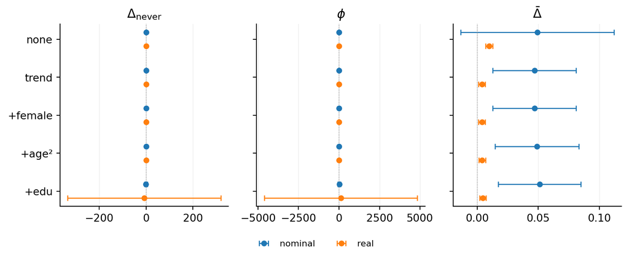

## Nominal vs real | CHN rural-first hukou, consumption/urban (unbalanced)

|  | nominal none | nominal trend | nominal +female | nominal +age<sup>2</sup> | nominal +edu | real none | real trend | real +female | real +age<sup>2</sup> | real +edu |
| --- | --- | --- | --- | --- | --- | --- | --- | --- | --- | --- |
| *Δ*<sub>never</sub> | 0.421*** | 0.074** | 0.074** | 0.105*** | 0.106*** | 0.145*** | -0.144*** | -0.144*** | -0.122*** | -0.121*** |
|  | (0.022) | (0.036) | (0.036) | (0.025) | (0.023) | (0.022) | (0.032) | (0.032) | (0.024) | (0.023) |
| *φ* | -0.893*** | 0.129 | 0.128 | -0.037 | -0.039 | -0.966*** | 0.059 | 0.059 | -0.056 | -0.055 |
|  | (0.070) | (0.193) | (0.193) | (0.152) | (0.153) | (0.082) | (0.156) | (0.156) | (0.134) | (0.133) |
| *Δ* | 0.481*** | 0.089*** | 0.089*** | 0.102*** | 0.104*** | 0.009*** | -0.007*** | -0.007*** | -0.007*** | -0.006*** |
|  | (0.022) | (0.022) | (0.022) | (0.022) | (0.022) | (0.001) | (0.001) | (0.001) | (0.001) | (0.001) |
| *J* p | 0.000 | 0.209 | 0.209 | 0.126 | 0.125 | 0.000 | 0.118 | 0.118 | 0.063 | 0.061 |
| converged | Y | Y | Y | Y | Y |  |  |  |  |  |
| *N* | 80,742 | 80,742 | 80,742 | 80,742 | 80,742 | 80,742 | 80,742 | 80,742 | 80,742 | 80,742 |
| runtime | 336s | 339s | 353s | 383s | 426s |  |  |  |  |  |

Results from *nominal*: 2026-05-12 23:52 | *real*: scraped from log

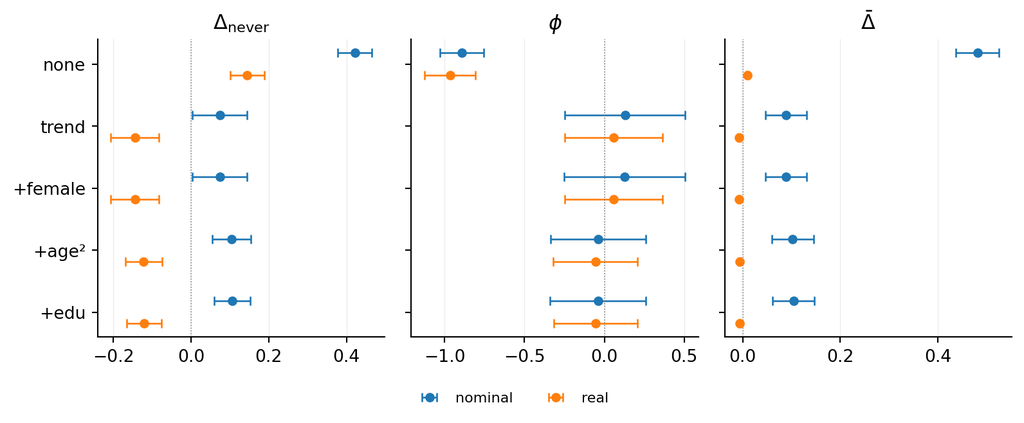

## Nominal vs real | CHN rural-only hukou, consumption/urban (unbalanced)

|  | nominal none | nominal trend | nominal +female | nominal +age<sup>2</sup> | nominal +edu | real none | real trend | real +female | real +age<sup>2</sup> | real +edu |
| --- | --- | --- | --- | --- | --- | --- | --- | --- | --- | --- |
| *Δ*<sub>never</sub> | 0.497*** | 0.075** | 0.075** | 0.098*** | 0.100*** | 0.196*** | -0.153*** | -0.152*** | -0.129*** | -0.127*** |
|  | (0.024) | (0.032) | (0.032) | (0.025) | (0.023) | (0.023) | (0.032) | (0.032) | (0.025) | (0.023) |
| *φ* | -0.289*** | 0.088 | 0.087 | -0.021 | -0.032 | -0.239** | 0.111 | 0.110 | 0.008 | -0.001 |
|  | (0.104) | (0.176) | (0.175) | (0.151) | (0.152) | (0.122) | (0.167) | (0.167) | (0.155) | (0.153) |
| *Δ* | 0.526*** | 0.085*** | 0.085*** | 0.097*** | 0.099*** | 0.011*** | -0.008*** | -0.008*** | -0.007*** | -0.007*** |
|  | (0.024) | (0.022) | (0.022) | (0.022) | (0.022) | (0.001) | (0.001) | (0.001) | (0.001) | (0.001) |
| *J* p | 0.000 | 0.286 | 0.285 | 0.208 | 0.200 | 0.000 | 0.214 | 0.213 | 0.127 | 0.119 |
| converged | Y | Y | Y | Y | Y |  |  |  |  |  |
| *N* | 75,748 | 75,748 | 75,748 | 75,748 | 75,748 | 75,748 | 75,748 | 75,748 | 75,748 | 75,748 |
| runtime | 265s | 271s | 296s | 326s | 366s |  |  |  |  |  |

Results from *nominal*: 2026-05-13 00:50 | *real*: scraped from log

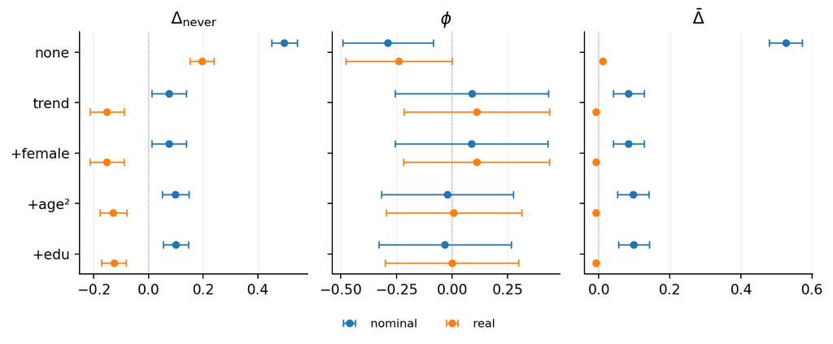

## Nominal vs real | CHN urban-first hukou, consumption/urban (unbalanced)

|  | nominal none | nominal trend | nominal +female | nominal +age<sup>2</sup> | nominal +edu | real none | real trend | real +female | real +age<sup>2</sup> | real +edu |
| --- | --- | --- | --- | --- | --- | --- | --- | --- | --- | --- |
| *Δ*<sub>never</sub> | 0.284*** | 0.106* | 0.107* | 0.074 | 0.006 | 0.100 | -0.068 | -0.067 | -0.102* | -0.160*** |
|  | (0.074) | (0.055) | (0.055) | (0.053) | (0.054) | (0.074) | (0.058) | (0.058) | (0.054) | (0.060) |
| *φ* | -1.324*** | -0.805*** | -0.804*** | -0.826*** | -0.973*** | -1.317*** | -0.829*** | -0.826*** | -0.864*** | -0.995*** |
|  | (0.165) | (0.162) | (0.162) | (0.158) | (0.169) | (0.195) | (0.184) | (0.184) | (0.174) | (0.056) |
| *Δ* | 0.330*** | 0.052 | 0.053 | 0.052 | 0.004 | 0.001 | -0.002*** | -0.002*** | -0.002*** | -0.005 |
|  | (0.050) | (0.054) | (0.054) | (0.054) | (0.378) | (0.001) | (0.001) | (0.001) | (0.001) | (0.040) |
| *J* p | 0.585 | 0.108 | 0.100 | 0.126 | 0.215 | 0.658 | 0.093 | 0.086 | 0.114 | 0.182 |
| converged | Y | Y | Y | Y | Y |  |  |  |  |  |
| *N* | 28,264 | 28,264 | 28,264 | 28,264 | 28,264 | 28,264 | 28,264 | 28,264 | 28,264 | 28,264 |
| runtime | 43s | 57s | 70s | 66s | 123s |  |  |  |  |  |

Results from *nominal*: 2026-05-13 00:36 | *real*: scraped from log

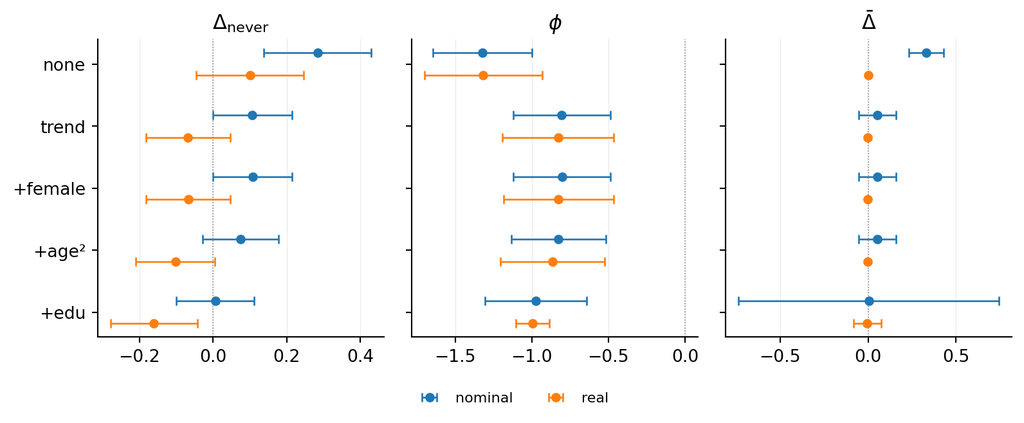

## Nominal vs real | CHN urban-only hukou, consumption/urban (unbalanced)

|  | nominal none | nominal trend | nominal +female | nominal +age<sup>2</sup> | nominal +edu | real none | real trend | real +female | real +age<sup>2</sup> | real +edu |
| --- | --- | --- | --- | --- | --- | --- | --- | --- | --- | --- |
| *Δ*<sub>never</sub> | 0.242*** | 0.078 | 0.079 | 0.045 | -0.024 | 0.065 | -0.089 | -0.088 | -0.125** | -0.184*** |
|  | (0.071) | (0.054) | (0.054) | (0.053) | (0.057) | (0.068) | (0.056) | (0.056) | (0.053) | (0.054) |
| *φ* | -1.276*** | -0.791*** | -0.798*** | -0.820*** | -0.976*** | -1.204*** | -0.798*** | -0.798*** | -0.829*** | -0.998*** |
|  | (0.137) | (0.155) | (0.158) | (0.155) | (0.172) | (0.146) | (0.166) | (0.166) | (0.157) | (0.170) |
| *Δ* | 0.295*** | 0.052 | 0.053 | 0.050 | 0.045 | 0.000 | -0.002*** | -0.002*** | -0.002*** | -0.002*** |
|  | (0.053) | (0.053) | (0.053) | (0.052) | (0.051) | (0.001) | (0.001) | (0.001) | (0.001) | (0.001) |
| *J* p | 0.759 | 0.174 | 0.163 | 0.230 | 0.303 | 0.693 | 0.117 | 0.109 | 0.165 | 0.137 |
| converged | Y | Y | Y | Y | Y |  |  |  |  |  |
| *N* | 26,155 | 26,155 | 26,155 | 26,155 | 26,155 | 26,155 | 26,155 | 26,155 | 26,155 | 26,155 |
| runtime | 26s | 39s | 47s | 49s | 58s |  |  |  |  |  |

Results from *nominal*: 2026-05-13 01:28 | *real*: scraped from log

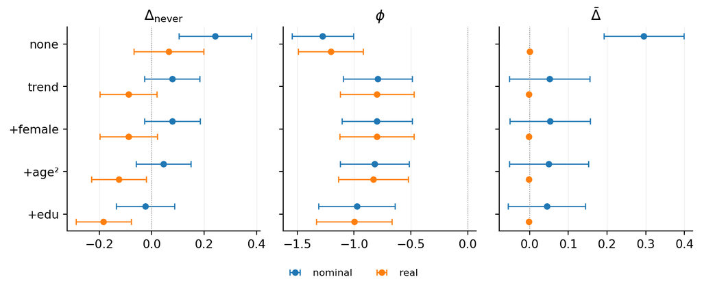